# Personal Loan Campaign Project

(All Life Bank)

### Description of Dataset:

- ID: Customer ID
- Age: Customer’s age in completed years
- Experience: #years of professional experience
- Income: Annual income of the customer (in thousand dollars)
- ZIP Code: Home Address ZIP code.
- Family: the Family size of the customer
- CCAvg: Average spending on credit cards per month (in thousand dollars)
- Education: Education Level. 1: Undergrad; 2: Graduate;3: Advanced/Professional
- Mortgage: Value of house mortgage if any. (in thousand dollars)
- Personal_Loan: Did this customer accept the personal loan offered in the last campaign?
- Securities_Account: Does the customer have securities account with the bank?
- CD_Account: Does the customer have a certificate of deposit (CD) account with the bank?
- Online: Do customers use internet banking facilities?
- CreditCard: Does the customer use a credit card issued by any other Bank (excluding All life Bank)?

### Objective

- To predict whether a liability customer will buy a personal loan or not.
- Which variables are most significant.
- Which segment of customers should be targeted more.

# 1. Initial Analysis / Structure of the Data

### Import the relevant Python Packages

```python
# this will help in making the Python code more structured automatically (good coding practice)
%load_ext nb_black

# Library to suppress warnings or deprecation notes
import warnings

warnings.filterwarnings("ignore")

# Libraries to help with reading and manipulating data

import pandas as pd
import numpy as np

# Library to split data
from sklearn.model_selection import train_test_split

# libaries to help with data visualization
import matplotlib.pyplot as plt
import seaborn as sns

# Removes the limit for the number of displayed columns
pd.set_option("display.max_columns", None)
# Sets the limit for the number of displayed rows
pd.set_option("display.max_rows", 200)

# Libraries to build decision tree classifier
from sklearn.tree import DecisionTreeClassifier
from sklearn import tree

# To tune different models
from sklearn.model_selection import GridSearchCV

# To get diferent metric scores
from sklearn.metrics import (
    f1_score,
    accuracy_score,
    recall_score,
    precision_score,
    confusion_matrix,
    plot_confusion_matrix,
    make_scorer,
)

# To build model for prediction

from sklearn.linear_model import LogisticRegression

# To get diferent metric scores
# To get diferent metric scores

from sklearn.metrics import (
    f1_score,
    accuracy_score,
    recall_score,
    precision_score,
    confusion_matrix,
    roc_auc_score,
    plot_confusion_matrix,
    precision_recall_curve,
    roc_curve,
)
```

```
The nb_black extension is already loaded. To reload it, use:
  %reload_ext nb_black
```

### Read the dataset

```python
data1 = pd.read_csv("Loan_Modelling.csv")
```

```python
# copying data to another varaible to avoid any changes to original data
loan1 = data1.copy()
```

### Checking the number of rows and columns

```python
loan1.shape  # find the number of rows and columns
```

```
(5000, 14)
```

Observation: The dataset has 5000 rows and 14 columns

### Viewing the first 5 and last 5 rows of the dataset

```python
loan1.head()
```

|  | ID | Age | Experience | Income | ZIPCode | Family | CCAvg | Education | Mortgage | Personal_Loan | Securities_Account | CD_Account | Online | CreditCard |
| --- | --- | --- | --- | --- | --- | --- | --- | --- | --- | --- | --- | --- | --- | --- |
| 0 | 1 | 25 | 1 | 49 | 91107 | 4 | 1.6 | 1 | 0 | 0 | 1 | 0 | 0 | 0 |
| 1 | 2 | 45 | 19 | 34 | 90089 | 3 | 1.5 | 1 | 0 | 0 | 1 | 0 | 0 | 0 |
| 2 | 3 | 39 | 15 | 11 | 94720 | 1 | 1.0 | 1 | 0 | 0 | 0 | 0 | 0 | 0 |
| 3 | 4 | 35 | 9 | 100 | 94112 | 1 | 2.7 | 2 | 0 | 0 | 0 | 0 | 0 | 0 |
| 4 | 5 | 35 | 8 | 45 | 91330 | 4 | 1.0 | 2 | 0 | 0 | 0 | 0 | 0 | 1 |

```python
loan1.tail()
```

|  | ID | Age | Experience | Income | ZIPCode | Family | CCAvg | Education | Mortgage | Personal_Loan | Securities_Account | CD_Account | Online | CreditCard |
| --- | --- | --- | --- | --- | --- | --- | --- | --- | --- | --- | --- | --- | --- | --- |
| 4995 | 4996 | 29 | 3 | 40 | 92697 | 1 | 1.9 | 3 | 0 | 0 | 0 | 0 | 1 | 0 |
| 4996 | 4997 | 30 | 4 | 15 | 92037 | 4 | 0.4 | 1 | 85 | 0 | 0 | 0 | 1 | 0 |
| 4997 | 4998 | 63 | 39 | 24 | 93023 | 2 | 0.3 | 3 | 0 | 0 | 0 | 0 | 0 | 0 |
| 4998 | 4999 | 65 | 40 | 49 | 90034 | 3 | 0.5 | 2 | 0 | 0 | 0 | 0 | 1 | 0 |
| 4999 | 5000 | 28 | 4 | 83 | 92612 | 3 | 0.8 | 1 | 0 | 0 | 0 | 0 | 1 | 1 |

### Check the datatypes of the columns

```python
loan1.info()
```

```
<class 'pandas.core.frame.DataFrame'>
RangeIndex: 5000 entries, 0 to 4999
Data columns (total 14 columns):
 #   Column              Non-Null Count  Dtype
---  ------              --------------  -----
 0   ID                  5000 non-null   int64
 1   Age                 5000 non-null   int64
 2   Experience          5000 non-null   int64
 3   Income              5000 non-null   int64
 4   ZIPCode             5000 non-null   int64
 5   Family              5000 non-null   int64
 6   CCAvg               5000 non-null   float64
 7   Education           5000 non-null   int64
 8   Mortgage            5000 non-null   int64
 9   Personal_Loan       5000 non-null   int64
 10  Securities_Account  5000 non-null   int64
 11  CD_Account          5000 non-null   int64
 12  Online              5000 non-null   int64
 13  CreditCard          5000 non-null   int64
dtypes: float64(1), int64(13)
memory usage: 547.0 KB
```

Observation

- All columns are int64, except CCAVg which is a float64.
- There are no object type columns
- Personal_Loan is the dependent variable

### Checking for Null values / Unique values / Duplicate rows

```python
# checking for unique values in ID column
loan1["ID"].nunique()
```

```
5000
```

Observation

- All ID values are unique

```python
loan1.drop(
    ["ID"], axis=1, inplace=True
)  # Dropping ID column as all values in the column are unique
```

```python
loan1.isnull().values.any()  # Check for any null values in the data set
```

```
False
```

Observation

- There are no null values in the data set

```python
loan1[loan1.duplicated()].count()
```

```
Age                   0
Experience            0
Income                0
ZIPCode               0
Family                0
CCAvg                 0
Education             0
Mortgage              0
Personal_Loan         0
Securities_Account    0
CD_Account            0
Online                0
CreditCard            0
dtype: int64
```

Observation

- There are no duplicate values in the dataset

### Summary of Data

```python
loan1.describe(include="all").T
```

|  | count | mean | std | min | 25% | 50% | 75% | max |
| --- | --- | --- | --- | --- | --- | --- | --- | --- |
| Age | 5000.0 | 45.338400 | 11.463166 | 23.0 | 35.0 | 45.0 | 55.0 | 67.0 |
| Experience | 5000.0 | 20.104600 | 11.467954 | -3.0 | 10.0 | 20.0 | 30.0 | 43.0 |
| Income | 5000.0 | 73.774200 | 46.033729 | 8.0 | 39.0 | 64.0 | 98.0 | 224.0 |
| ZIPCode | 5000.0 | 93169.257000 | 1759.455086 | 90005.0 | 91911.0 | 93437.0 | 94608.0 | 96651.0 |
| Family | 5000.0 | 2.396400 | 1.147663 | 1.0 | 1.0 | 2.0 | 3.0 | 4.0 |
| CCAvg | 5000.0 | 1.937938 | 1.747659 | 0.0 | 0.7 | 1.5 | 2.5 | 10.0 |
| Education | 5000.0 | 1.881000 | 0.839869 | 1.0 | 1.0 | 2.0 | 3.0 | 3.0 |
| Mortgage | 5000.0 | 56.498800 | 101.713802 | 0.0 | 0.0 | 0.0 | 101.0 | 635.0 |
| Personal_Loan | 5000.0 | 0.096000 | 0.294621 | 0.0 | 0.0 | 0.0 | 0.0 | 1.0 |
| Securities_Account | 5000.0 | 0.104400 | 0.305809 | 0.0 | 0.0 | 0.0 | 0.0 | 1.0 |
| CD_Account | 5000.0 | 0.060400 | 0.238250 | 0.0 | 0.0 | 0.0 | 0.0 | 1.0 |
| Online | 5000.0 | 0.596800 | 0.490589 | 0.0 | 0.0 | 1.0 | 1.0 | 1.0 |
| CreditCard | 5000.0 | 0.294000 | 0.455637 | 0.0 | 0.0 | 0.0 | 1.0 | 1.0 |

Observation:

- Experience has negative values, it needs to be explored further.
- Customer Age varies from 23 and 67, average is around 45
- Income ranges from 8k to 224k dollars, median is around 64. So looks like having outliers
- Credit Card Average ranges from 0 to 10k dollars
- Education ranges from 1 to 3
- Value of Mortgage ranges from 0 to 635k dollars
- Personal Loan / Securitie Account / CD_Account, Online and CreditCard are all boolean values either 0 and 1

### Data PreProcessing Handling negative values of Experience

```python
# Exploring the Experience column
cat_columns = ["Experience"]
for i in cat_columns:
    print(loan1[i].value_counts().sort_values(ascending=False))
```

```
 32    154
 20    148
 9     147
 5     146
 23    144
 35    143
 25    142
 28    138
 18    137
 19    135
 26    134
 24    131
 3     129
 14    127
 16    127
```

[output cut: 33 more lines]

Observation:

- There are negative values ( -1, -2 and -3), Considering the negative values as data entry errorsSo converting them to positive values.

```python
# Convert the negative numbers in Experience to their absolute values (considering it as data entry error)
loan1["Experience"] = loan1["Experience"].abs()
```

## EDA

### Univariate Analysis

```python
# function to create labeled barplots


def labeled_barplot(data, feature, perc=False, n=None):
    """
    Barplot with percentage at the top

    data: dataframe
    feature: dataframe column
    perc: whether to display percentages instead of count (default is False)
    n: displays the top n category levels (default is None, i.e., display all levels)
    """

    total = len(data[feature])  # length of the column
    count = data[feature].nunique()
    if n is None:
        plt.figure(figsize=(count + 2, 6))
    else:
        plt.figure(figsize=(n + 2, 6))

    plt.xticks(rotation=90, fontsize=15)
    ax = sns.countplot(
        data=data,
        x=feature,
        palette="Paired",
        order=data[feature].value_counts().index[:n].sort_values(),
    )

    for p in ax.patches:
        if perc == True:
            label = "{:.1f}%".format(
                100 * p.get_height() / total
            )  # percentage of each class of the category
        else:
            label = p.get_height()  # count of each level of the category

        x = p.get_x() + p.get_width() / 2  # width of the plot
        y = p.get_height()  # height of the plot

        ax.annotate(
            label,
            (x, y),
            ha="center",
            va="center",
            size=12,
            xytext=(0, 5),
            textcoords="offset points",
        )  # annotate the percentage

    plt.show()  # show the plot
```

```python
# function to plot a boxplot and a histogram along the same scale.


def histogram_boxplot(data, feature, figsize=(12, 7), kde=False, bins=None):
    """
    Boxplot and histogram combined

    data: dataframe
    feature: dataframe column
    figsize: size of figure (default (12,7))
    kde: whether to the show density curve (default False)
    bins: number of bins for histogram (default None)
    """
    f2, (ax_box2, ax_hist2) = plt.subplots(
        nrows=2,  # Number of rows of the subplot grid= 2
        sharex=True,  # x-axis will be shared among all subplots
        gridspec_kw={"height_ratios": (0.25, 0.75)},
        figsize=figsize,
    )  # creating the 2 subplots
    sns.boxplot(
        data=data, x=feature, ax=ax_box2, showmeans=True, color="violet"
    )  # boxplot will be created and a star will indicate the mean value of the column
    sns.histplot(
        data=data, x=feature, kde=kde, ax=ax_hist2, bins=bins, palette="winter"
    ) if bins else sns.histplot(
        data=data, x=feature, kde=kde, ax=ax_hist2
    )  # For histogram
    ax_hist2.axvline(
        data[feature].mean(), color="green", linestyle="--"
    )  # Add mean to the histogram
    ax_hist2.axvline(
        data[feature].median(), color="black", linestyle="-"
    )  # Add median to the histogram
```

### Observation on Personal Loan

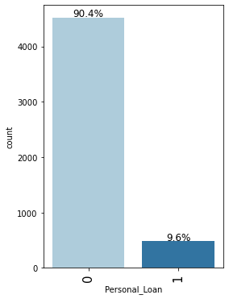

```python
labeled_barplot(loan1, "Personal_Loan", perc=True)
```

Observation

- 9.6% of Customers has Personal Loan with the bank

### Observation on Mortgage

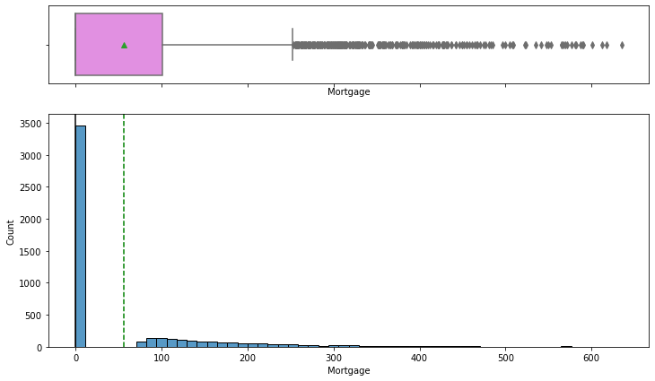

```python
histogram_boxplot(loan1, "Mortgage")
```

```python
loan1[loan1["Mortgage"] == 0]["Personal_Loan"].value_counts()
```

```
0    3150
1     312
Name: Personal_Loan, dtype: int64
```

Observation

### Observation on Age

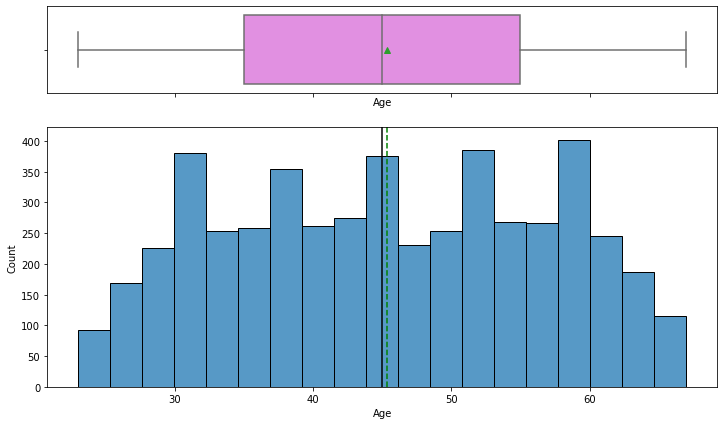

```python
histogram_boxplot(loan1, "Age")
```

Observation

- Age of Customers is uniformly distributed

### Observation on Securities Account

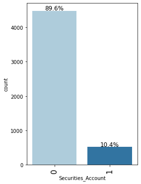

```python
labeled_barplot(loan1, "Securities_Account", perc=True)
```

Observation:

- 10% of Customers has Securities Account

### Observation on CD Account

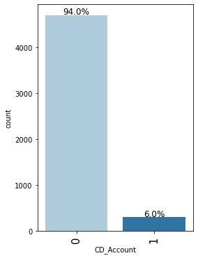

```python
labeled_barplot(loan1, "CD_Account", perc=True)
```

Observation

- 6% of customers have CD Account

### Observation on Online Customers

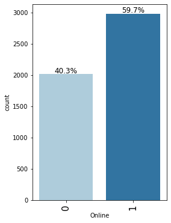

```python
labeled_barplot(loan1, "Online", perc=True)
```

Observation

- Around 60% of Customers have online account

### Observations on Credit Card

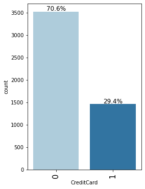

```python
labeled_barplot(loan1, "CreditCard", perc=True)
```

Observation

- Around 29% of Customers have a Credit Card issues by any other bank

### Observations on Age, Experience, Income , Mortgage and CCAvg

```
array([[<AxesSubplot:title={'center':'Age'}>,
        <AxesSubplot:title={'center':'Experience'}>],
       [<AxesSubplot:title={'center':'Income'}>,
        <AxesSubplot:title={'center':'Mortgage'}>],
       [<AxesSubplot:title={'center':'CCAvg'}>, <AxesSubplot:>],
       [<AxesSubplot:>, <AxesSubplot:>],
       [<AxesSubplot:>, <AxesSubplot:>],
       [<AxesSubplot:>, <AxesSubplot:>],
       [<AxesSubplot:>, <AxesSubplot:>],
       [<AxesSubplot:>, <AxesSubplot:>],
       [<AxesSubplot:>, <AxesSubplot:>],
       [<AxesSubplot:>, <AxesSubplot:>],
       [<AxesSubplot:>, <AxesSubplot:>],
       [<AxesSubplot:>, <AxesSubplot:>],
       [<AxesSubplot:>, <AxesSubplot:>],
       [<AxesSubplot:>, <AxesSubplot:>]], dtype=object)
```

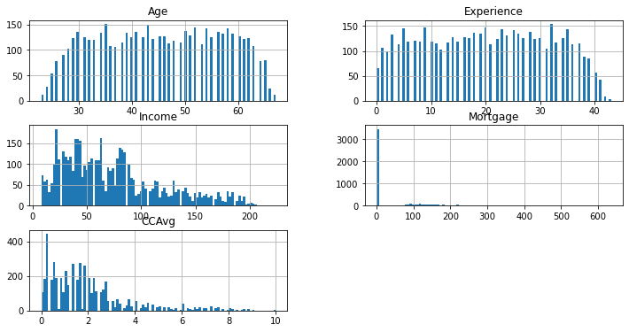

```python
columns = [
    "Age",
    "Experience",
    "Income",
    "Mortgage",
    "CCAvg",
]  # Excluding Outcome column which has only
# columns = list(loan1)[0:-1]
loan1[columns].hist(stacked=False, bins=100, figsize=(12, 30), layout=(14, 2))
# Histogram of selected columns
```

Observation:

### Feature Engineering

```python
# Since the numeric values of Zip Codes is not usefl for the analysis, converting it to County Names
```

### Converting Zipcode numerals to name of the County using uszipcode library

```python
from uszipcode import SearchEngine

search = SearchEngine()
county = []
for i in np.arange(0, len(loan1["ZIPCode"])):
    zipcode = search.by_zipcode(loan1["ZIPCode"][i])
    county.append(zipcode.county)

loan1["County"] = county  # Adding County as the name of the column
loan1.head()
```

|  | Age | Experience | Income | ZIPCode | Family | CCAvg | Education | Mortgage | Personal_Loan | Securities_Account | CD_Account | Online | CreditCard | County |
| --- | --- | --- | --- | --- | --- | --- | --- | --- | --- | --- | --- | --- | --- | --- |
| 0 | 25 | 1 | 49 | 91107 | 4 | 1.6 | 1 | 0 | 0 | 1 | 0 | 0 | 0 | Los Angeles County |
| 1 | 45 | 19 | 34 | 90089 | 3 | 1.5 | 1 | 0 | 0 | 1 | 0 | 0 | 0 | Los Angeles County |
| 2 | 39 | 15 | 11 | 94720 | 1 | 1.0 | 1 | 0 | 0 | 0 | 0 | 0 | 0 | Alameda County |
| 3 | 35 | 9 | 100 | 94112 | 1 | 2.7 | 2 | 0 | 0 | 0 | 0 | 0 | 0 | San Francisco County |
| 4 | 35 | 8 | 45 | 91330 | 4 | 1.0 | 2 | 0 | 0 | 0 | 0 | 0 | 1 | Los Angeles County |

```python
loan1.info()
```

```
<class 'pandas.core.frame.DataFrame'>
RangeIndex: 5000 entries, 0 to 4999
Data columns (total 14 columns):
 #   Column              Non-Null Count  Dtype
---  ------              --------------  -----
 0   Age                 5000 non-null   int64
 1   Experience          5000 non-null   int64
 2   Income              5000 non-null   int64
 3   ZIPCode             5000 non-null   int64
 4   Family              5000 non-null   int64
 5   CCAvg               5000 non-null   float64
 6   Education           5000 non-null   int64
 7   Mortgage            5000 non-null   int64
 8   Personal_Loan       5000 non-null   int64
 9   Securities_Account  5000 non-null   int64
 10  CD_Account          5000 non-null   int64
 11  Online              5000 non-null   int64
 12  CreditCard          5000 non-null   int64
 13  County              4966 non-null   object
dtypes: float64(1), int64(12), object(1)
memory usage: 547.0+ KB
```

```python
# Check for any null values in the data set
loan1[loan1["County"].isnull()].count()
```

```
Age                   34
Experience            34
Income                34
ZIPCode               34
Family                34
CCAvg                 34
Education             34
Mortgage              34
Personal_Loan         34
Securities_Account    34
CD_Account            34
Online                34
CreditCard            34
County                 0
dtype: int64
```

Observation

- There are 34 rows in the data set where County is mentioned as Null

```python
# Replacing Null values with Unknown CA County , as there is only  a small fraction of rows 34/5000

loan1["County"] = loan1["County"].fillna("Unknown CA County")
```

```python
loan1[loan1["County"].isnull()].count()
```

```
Age                   0
Experience            0
Income                0
ZIPCode               0
Family                0
CCAvg                 0
Education             0
Mortgage              0
Personal_Loan         0
Securities_Account    0
CD_Account            0
Online                0
CreditCard            0
County                0
dtype: int64
```

Observation

- There are no null values for County now.

```python
loan1.drop(
    ["ZIPCode"], axis=1, inplace=True
)  # Dropping ZipCode column as all values are converted to County Names
```

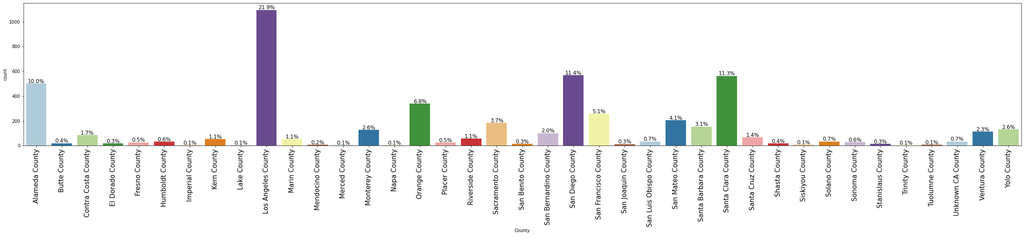

```python
labeled_barplot(loan1, "County", perc=True)
```

Observation

- Los Angeles County is where most of the customers are, followed by San Diego , Santa Clara and Alameda

### Bivariate Analysis

```python
# function to plot stacked bar chart


def stacked_barplot(data, predictor, target):
    """
    Print the category counts and plot a stacked bar chart

    data: dataframe
    predictor: independent variable
    target: target variable
    """
    count = data[predictor].nunique()
    sorter = data[target].value_counts().index[-1]
    tab1 = pd.crosstab(data[predictor], data[target], margins=True).sort_values(
        by=sorter, ascending=False
    )
    print(tab1)
    print("-" * 120)
    tab = pd.crosstab(data[predictor], data[target], normalize="index").sort_values(
        by=sorter, ascending=False
    )
    tab.plot(kind="bar", stacked=True, figsize=(count + 5, 6))
    plt.legend(
        loc="lower left", frameon=False,
    )
    plt.legend(loc="upper left", bbox_to_anchor=(1, 1))
    plt.show()
```

### Age vs Personal Loan

```
Personal_Loan     0    1   All
Age
All            4520  480  5000
34              116   18   134
30              119   17   136
36               91   16   107
63               92   16   108
35              135   16   151
33              105   15   120
52              130   15   145
29              108   15   123
54              128   15   143
43              134   15   149
42              112   14   126
56              121   14   135
```

[output cut: 34 more lines]

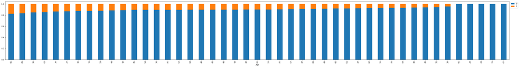

```python
stacked_barplot(loan1, "Age", "Personal_Loan")
```

Observation

- Customers in age 65 have personal loans the most, followed by Ages 26, 36 and 63
- There is no definite pattern of Age group of customers who has the loans
- However, the lower age groups of (23, 24 and 25) and age group 66 and 67 do not have personal loans. This could be due to their lack of income (students) or close to retirement

```
Personal_Loan     0    1   All
Income
All            4520  480  5000
130               8   11    19
182               2   11    13
158               8   10    18
135               8   10    18
179               8    9    17
141              15    9    24
154              12    9    21
123               9    9    18
184               3    9    12
142               7    8    15
131              11    8    19
129              15    8    23
```

[output cut: 151 more lines]

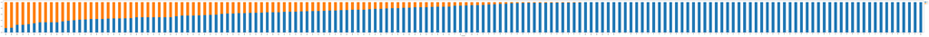

```python
stacked_barplot(loan1, "Income", "Personal_Loan")
```

Observation

- Customers with income levels 80k - 192K have personal loans
- Customers with very high income levels 198-224k do not have personal loans
- Also Customers with low income levels 80k and below do not have personal loans

### Family Size vs Personal Loan

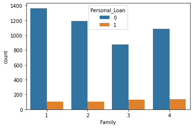

```python
# stacked_barplot(loan1, "Family", "Personal_Loan")
sns.countplot(data=loan1, x="Family", hue="Personal_Loan")
```

Observation

- 3 and 4 member families tend to be more willing to take a personal loan , compared to 2 member families (couple) or singles

```
Personal_Loan     0    1   All
Experience
All            4520  480  5000
9               127   20   147
8               101   18   119
3               116   17   133
20              131   17   148
12               86   16   102
5               132   14   146
32              140   14   154
26              120   14   134
25              128   14   142
19              121   14   135
16              114   13   127
37              103   13   116
```

[output cut: 33 more lines]

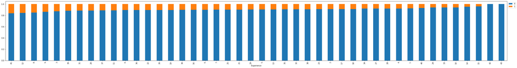

```python
stacked_barplot(loan1, "Experience", "Personal_Loan")
```

Observation

- There is no experience level and appetitite for personal loan in a definitive pattern . In this example , the customers with max number of years of experience 42 and 43 do not have personal loans

### Education vs Personal Loan

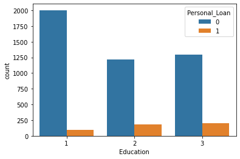

```python
sns.countplot(data=loan1, x="Education", hue="Personal_Loan")
```

Observation

- As number of years of education increases, more customers tend to avail the Personal Loan

### Securities Account vs Personal Loan

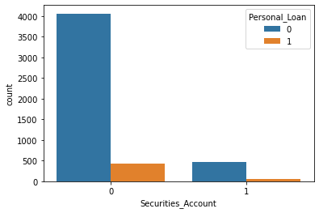

```python
sns.countplot(data=loan1, x="Securities_Account", hue="Personal_Loan")
```

Observation

- Most Customers without Security Account tend to avail Personal Loans

### CD Account vs Personal Loan

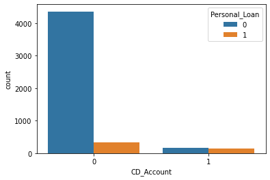

```python
sns.countplot(data=loan1, x="CD_Account", hue="Personal_Loan")
```

Observation

- Most Customers without CD Account tend to avail Personal Loans

### Online vs Personal Loan

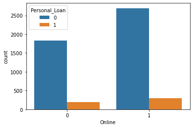

```python
sns.countplot(data=loan1, x="Online", hue="Personal_Loan")
```

Observation

- Customers use Internet Banking facilities tend to avail Personal Loan

### CreditCard vs Personal Loan

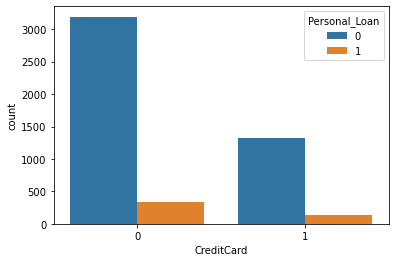

```python
sns.countplot(data=loan1, x="CreditCard", hue="Personal_Loan")
```

Observation

- Customers without credit card tend to avail Personal Loans

### Correlation between numerical variables

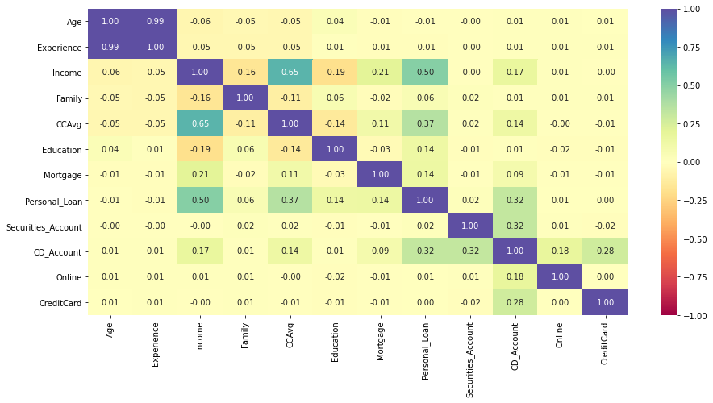

```python
plt.figure(figsize=(15, 7))
sns.heatmap(loan1.corr(), annot=True, vmin=-1, vmax=1, fmt=".2f", cmap="Spectral")
plt.show()
```

Observation

```python
loan1.drop(
    ["Age"], axis=1, inplace=True
)  # Dropping Age column as all values are highly corelated to Experience
```

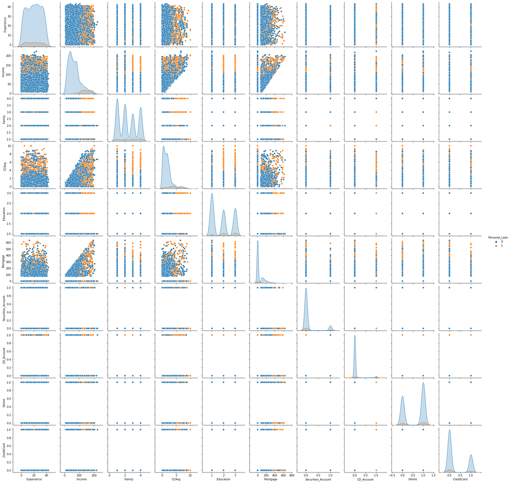

```python
sns.pairplot(data=loan1, hue="Personal_Loan")
plt.show()
```

## Summary of EDA

#### About the data set

- The dataset has 5000 rows and 14 columns
- There are no duplicate rows
- Personal_Loan is the dependent variable
- There are no NUll values
- Experience has negative values, it needs to be explored further.
- Customer Age varies from 23 and 67, average is around 45
- Income ranges from 8k to 224k dollars, median is around 64. So looks like haviong outliers
- Credit Card Average ranges from 0 to 10k dollars
- Education ranges from 1 to 3
- Value of Mortgage ranges from 0 to 635k dollars
- Personal Loan / Securitie Account / CD_Account, Online and CreditCard are all boolean values either 0 and 1

#### Data Cleanup

- Negative values of Experience is converted to Absolute value considering it as Data Entry error
- Using uszipcode library, Zipcode numerals are converted to County
- 34 Counties have Null values, so it is converted to string "Unknown CA County"
- The ID column was unique , so we dropped the column
- Dropping Age column as all values are highly corelated to Experience

### Model evaluation criterion

### Model can make wrong predictions as:

1. Predicting a customer is going to become a Personal Loan Customer - Loss of resources
2. Predicting a customer is not going to be a Perosnal Loan Customer but in reality the customer will likely avail of the Personal Loan - Loss of opportunity

### Which Loss is greater ?

- Loss of opportunity will be the greater loss as the bank will be losing a potential customer for Personal Loan.

### How to reduce this loss i.e need to reduce False Negatives ?

- Bank would want to reduce false negatives, this can be done by maximizing the Recall. Greater the recall lesser the chances of false negatives.
- The model_performance_classification_sklearn_with_threshold function will be used to check the model performance of models.
- The confusion_matrix_sklearn_with_threshold function will be used to plot confusion matrix.

```python
# defining a function to compute different metrics to check performance of a classification model built using sklearn

def model_performance_classification_sklearn_with_threshold(model, predictors, target, threshold=0.5):
    """
    Function to compute different metrics, based on the threshold specified, to check classification model performance

    model: classifier
    predictors: independent variables
    target: dependent variable
    threshold: threshold for classifying the observation as class 1
    """

    # predicting using the independent variables
    pred_prob = model.predict_proba(predictors)[:, 1]
    pred_thres = pred_prob > threshold
    pred = np.round(pred_thres)

    acc = accuracy_score(target, pred)  # to compute Accuracy
    recall = recall_score(target, pred)  # to compute Recall
    precision = precision_score(target, pred)  # to compute Precision
    f1 = f1_score(target, pred)  # to compute F1-score

    # creating a dataframe of metrics
    df_perf = pd.DataFrame(
        {
            "Accuracy": acc,
            "Recall": recall,
            "Precision": precision,
            "F1": f1,
        },
        index=[0],
    )

    return df_perf
```

```python
# defining a function to plot the confusion_matrix of a classification model built using sklearn
def confusion_matrix_sklearn_with_threshold(model, predictors, target, threshold=0.5):
    """
    To plot the confusion_matrix, based on the threshold specified, with percentages

    model: classifier
    predictors: independent variables
    target: dependent variable
    threshold: threshold for classifying the observation as class 1
    """
    pred_prob = model.predict_proba(predictors)[:, 1]
    pred_thres = pred_prob > threshold
    y_pred = np.round(pred_thres)

    cm = confusion_matrix(target, y_pred)
    labels = np.asarray(
        [
            ["{0:0.0f}".format(item) + "\n{0:.2%}".format(item / cm.flatten().sum())]
            for item in cm.flatten()
        ]
    ).reshape(2, 2)

    plt.figure(figsize=(6, 4))
    sns.heatmap(cm, annot=labels, fmt="")
    plt.ylabel("True label")
    plt.xlabel("Predicted label")
```

### Outlier Detection and Treatment

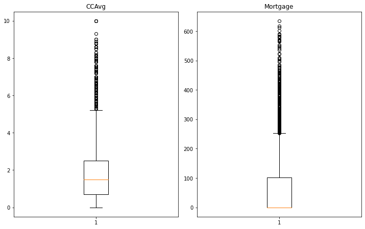

```python
outlier_cols = ["CCAvg", "Mortgage"]
plt.figure(figsize=(20, 30))

for i, variable in enumerate(outlier_cols):
    plt.subplot(5, 4, i + 1)
    plt.boxplot(loan1[variable], whis=1.5)
    plt.tight_layout()
    plt.title(variable)

plt.show()
```

```python
# functions to treat outliers by flooring and capping


def treat_outliers(df, col):
    """
    Treats outliers in a variable

    df: dataframe
    col: dataframe column
    """
    Q1 = df[col].quantile(0.25)  # 25th quantile
    Q3 = df[col].quantile(0.75)  # 75th quantile
    IQR = Q3 - Q1
    Lower_Whisker = Q1 - 1.5 * IQR
    Upper_Whisker = Q3 + 1.5 * IQR

    # all the values smaller than Lower_Whisker will be assigned the value of Lower_Whisker
    # all the values greater than Upper_Whisker will be assigned the value of Upper_Whisker
    df[col] = np.clip(df[col], Lower_Whisker, Upper_Whisker)

    return df


def treat_outliers_all(df, col_list):
    """
    Treat outliers in a list of variables

    df: dataframe
    col_list: list of dataframe columns
    """
    for c in col_list:
        df = treat_outliers(df, c)

    return df
```

```python
loan1 = treat_outliers_all(loan1, outlier_cols)
```

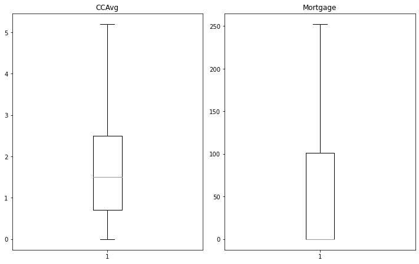

```python
plt.figure(figsize=(20, 30))

for i, variable in enumerate(outlier_cols):
    plt.subplot(5, 4, i + 1)
    plt.boxplot(loan1[variable], whis=1.5)
    plt.tight_layout()
    plt.title(variable)

plt.show()
```

```python
loan1.head()
```

|  | Experience | Income | Family | CCAvg | Education | Mortgage | Personal_Loan | Securities_Account | CD_Account | Online | CreditCard | County |
| --- | --- | --- | --- | --- | --- | --- | --- | --- | --- | --- | --- | --- |
| 0 | 1 | 49 | 4 | 1.6 | 1 | 0.0 | 0 | 1 | 0 | 0 | 0 | Los Angeles County |
| 1 | 19 | 34 | 3 | 1.5 | 1 | 0.0 | 0 | 1 | 0 | 0 | 0 | Los Angeles County |
| 2 | 15 | 11 | 1 | 1.0 | 1 | 0.0 | 0 | 0 | 0 | 0 | 0 | Alameda County |
| 3 | 9 | 100 | 1 | 2.7 | 2 | 0.0 | 0 | 0 | 0 | 0 | 0 | San Francisco County |
| 4 | 8 | 45 | 4 | 1.0 | 2 | 0.0 | 0 | 0 | 0 | 0 | 1 | Los Angeles County |

### Creating training and testing data sets

```python
X = loan1.drop(["Personal_Loan"], axis=1)
Y = loan1["Personal_Loan"]

X = pd.get_dummies(X, drop_first=True)

# Splitting data in train and test sets
X_train, X_test, y_train, y_test = train_test_split(
    X, Y, test_size=0.30, random_state=1
)
```

```python
print("Shape of Training set : ", X_train.shape)
print("Shape of test set : ", X_test.shape)
print("Percentage of classes in training set:")
print(y_train.value_counts(normalize=True))
print("Percentage of classes in test set:")
print(y_test.value_counts(normalize=True))
```

```
Shape of Training set :  (3500, 48)
Shape of test set :  (1500, 48)
Percentage of classes in training set:
0    0.905429
1    0.094571
Name: Personal_Loan, dtype: float64
Percentage of classes in test set:
0    0.900667
1    0.099333
Name: Personal_Loan, dtype: float64
```

## Logistic Regression

```python
# There are different solvers available in Sklearn logistic regression
# The newton-cg solver is faster for high-dimensional data

model = LogisticRegression(solver="newton-cg", random_state=1)
lg = model.fit(X_train, y_train)
```

### Finding the coefficients

```python
log_odds = lg.coef_[0]
pd.DataFrame(log_odds, X_train.columns, columns=["coef"]).T
```

|  | Experience | Income | Family | CCAvg | Education | Mortgage | Securities_Account | CD_Account | Online | CreditCard | County_Butte County | County_Contra Costa County | County_El Dorado County | County_Fresno County | County_Humboldt County | County_Imperial County | County_Kern County | County_Lake County | County_Los Angeles County | County_Marin County | County_Mendocino County | County_Merced County | County_Monterey County | County_Napa County | County_Orange County | County_Placer County | County_Riverside County | County_Sacramento County | County_San Benito County | … |
| --- | --- | --- | --- | --- | --- | --- | --- | --- | --- | --- | --- | --- | --- | --- | --- | --- | --- | --- | --- | --- | --- | --- | --- | --- | --- | --- | --- | --- | --- | --- |
| coef | 0.008423 | 0.051182 | 0.741898 | 0.406771 | 1.699589 | 0.001164 | -0.876211 | 3.25475 | -0.587279 | -1.004299 | -0.248952 | 0.714844 | -0.240739 | -0.009579 | -0.347144 | -0.015416 | 0.549538 | -0.004843 | 0.030813 | 0.452814 | -0.032665 | -0.177013 | -0.00613 | -0.006241 | -0.179221 | 0.668906 | 0.984755 | 0.041006 | -0.242791 | … |

### Observations from Coefficients

- Coefficients of Experience, Income, Family, CCAvg, Education, Mortgage, CD_Account and categorical variables of County are positive, an increase in these will lead to an increase in chances of a customer becoming a Personal Loan Customer.
- Coefficients of Securities_Account, Online, CreditCard and some categorical variables of County are negative, a increase in these will lead to an decrease in chances of a customer becoming a Personal Loan Customer.

### Convertings Co-efficients to Odds

```python
# converting coefficients to odds
odds = np.exp(lg.coef_[0])

# finding the percentage change
perc_change_odds = (np.exp(lg.coef_[0]) - 1) * 100

# removing limit from number of columns to display
pd.set_option("display.max_columns", None)

# adding the odds to a dataframe
pd.DataFrame({"Odds": odds, "Change_odd%": perc_change_odds}, index=X_train.columns).T
```

|  | Experience | Income | Family | CCAvg | Education | Mortgage | Securities_Account | CD_Account | Online | CreditCard | County_Butte County | County_Contra Costa County | County_El Dorado County | County_Fresno County | County_Humboldt County | County_Imperial County | County_Kern County | County_Lake County | County_Los Angeles County | County_Marin County | County_Mendocino County | County_Merced County | County_Monterey County | County_Napa County | County_Orange County | County_Placer County | County_Riverside County | County_Sacramento County | County_San Benito County | … |
| --- | --- | --- | --- | --- | --- | --- | --- | --- | --- | --- | --- | --- | --- | --- | --- | --- | --- | --- | --- | --- | --- | --- | --- | --- | --- | --- | --- | --- | --- | --- |
| Odds | 1.008459 | 1.052514 | 2.099918 | 1.501960 | 5.471700 | 1.001164 | 0.416357 | 25.913145 | 0.555838 | 0.366301 | 0.779617 | 2.043868 | 0.786047 | 0.990466 | 0.706704 | 0.984702 | 1.732452 | 0.995168 | 1.031293 | 1.572732 | 0.967863 | 0.837769 | 0.993889 | 0.993779 | 0.835921 | 1.952101 | 2.677157 | 1.041859 | 0.784436 | … |
| Change_odd% | 0.845888 | 5.251392 | 109.991795 | 50.195984 | 447.170003 | 0.116431 | -58.364261 | 2491.314503 | -44.416232 | -63.369878 | -22.038258 | 104.386793 | -21.395320 | -0.953355 | -29.329647 | -1.529768 | 73.245203 | -0.483176 | 3.129300 | 57.273212 | -3.213739 | -16.223122 | -0.611150 | -0.622108 | -16.407891 | 95.210113 | 167.715698 | 4.185856 | -21.556435 | … |

### Checking Model Performance on Training Set

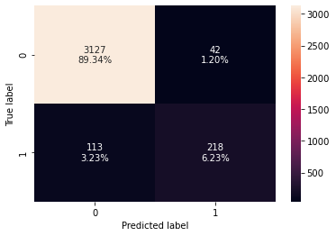

```python
# creating confusion matrix
confusion_matrix_sklearn_with_threshold(lg, X_train, y_train)
```

```python
log_reg_model_train_perf = model_performance_classification_sklearn_with_threshold(
    lg, X_train, y_train
)

print("Training performance:")
log_reg_model_train_perf
```

```
Training performance:
```

|  | Accuracy | Recall | Precision | F1 |
| --- | --- | --- | --- | --- |
| 0 | 0.955714 | 0.65861 | 0.838462 | 0.737733 |

### ROC-AUC on Training Set

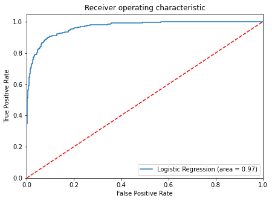

```python
logit_roc_auc_train = roc_auc_score(y_train, lg.predict_proba(X_train)[:, 1])
fpr, tpr, thresholds = roc_curve(y_train, lg.predict_proba(X_train)[:, 1])
plt.figure(figsize=(7, 5))
plt.plot(fpr, tpr, label="Logistic Regression (area = %0.2f)" % logit_roc_auc_train)
plt.plot([0, 1], [0, 1], "r--")
plt.xlim([0.0, 1.0])
plt.ylim([0.0, 1.05])
plt.xlabel("False Positive Rate")
plt.ylabel("True Positive Rate")
plt.title("Receiver operating characteristic")
plt.legend(loc="lower right")
plt.show()
```

### Model Performance Improvement

### Optimal Threshold

```python
# Optimal threshold as per AUC-ROC curve
# The optimal cut off would be where tpr is high and fpr is low
fpr, tpr, thresholds = roc_curve(y_train, lg.predict_proba(X_train)[:, 1])

optimal_idx = np.argmax(tpr - fpr)
optimal_threshold_auc_roc = thresholds[optimal_idx]
print(optimal_threshold_auc_roc)
```

```
0.11563508212873443
```

### Checking Model Performance with Optimal Performance Threshold

```python
# checking model performance for this model
log_reg_model_train_perf_threshold_auc_roc = model_performance_classification_sklearn_with_threshold(
    lg, X_train, y_train, threshold=optimal_threshold_auc_roc
)
print("Training performance:")
log_reg_model_train_perf_threshold_auc_roc
```

```
Training performance:
```

|  | Accuracy | Recall | Precision | F1 |
| --- | --- | --- | --- | --- |
| 0 | 0.909143 | 0.897281 | 0.511188 | 0.651316 |

Observation

- Model is now giving a higher value for Recall 0.89

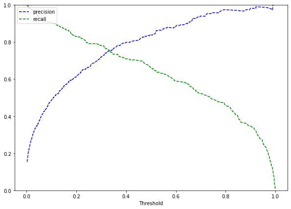

```python
y_scores = lg.predict_proba(X_train)[:, 1]
prec, rec, tre = precision_recall_curve(y_train, y_scores,)


def plot_prec_recall_vs_tresh(precisions, recalls, thresholds):
    plt.plot(thresholds, precisions[:-1], "b--", label="precision")
    plt.plot(thresholds, recalls[:-1], "g--", label="recall")
    plt.xlabel("Threshold")
    plt.legend(loc="upper left")
    plt.ylim([0, 1])


plt.figure(figsize=(10, 7))
plot_prec_recall_vs_tresh(prec, rec, tre)
plt.show()
```

```python
# setting the threshold
optimal_threshold_curve = 0.3
```

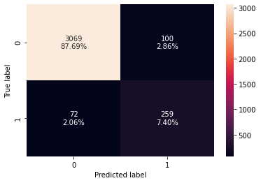

```python
# creating confusion matrix
confusion_matrix_sklearn_with_threshold(
    lg, X_train, y_train, threshold=optimal_threshold_curve
)
```

```python
log_reg_model_train_perf_threshold_curve = model_performance_classification_sklearn_with_threshold(
    lg, X_train, y_train, threshold=optimal_threshold_curve
)
print("Training performance:")
log_reg_model_train_perf_threshold_curve
```

```
Training performance:
```

|  | Accuracy | Recall | Precision | F1 |
| --- | --- | --- | --- | --- |
| 0 | 0.950857 | 0.782477 | 0.721448 | 0.750725 |

Observation

```python
# training performance comparison

models_train_comp_df = pd.concat(
    [
        log_reg_model_train_perf.T,
        log_reg_model_train_perf_threshold_auc_roc.T,
        log_reg_model_train_perf_threshold_curve.T,
    ],
    axis=1,
)
models_train_comp_df.columns = [
    "Logistic Regression sklearn",
    "Logistic Regression-0.11 Threshold",
    "Logistic Regression-0.30 Threshold",
]

print("Training performance comparison:")
models_train_comp_df
```

```
Training performance comparison:
```

|  | Logistic Regression sklearn | Logistic Regression-0.11 Threshold | Logistic Regression-0.30 Threshold |
| --- | --- | --- | --- |
| Accuracy | 0.955714 | 0.909143 | 0.950857 |
| Recall | 0.658610 | 0.897281 | 0.782477 |
| Precision | 0.838462 | 0.511188 | 0.721448 |
| F1 | 0.737733 | 0.651316 | 0.750725 |

### Performance on Test Set

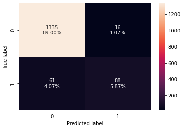

```python
# creating confusion matrix
confusion_matrix_sklearn_with_threshold(lg, X_test, y_test)
```

```python
log_reg_model_test_perf = model_performance_classification_sklearn_with_threshold(
    lg, X_test, y_test
)

print("Test set performance:")
log_reg_model_test_perf
```

```
Test set performance:
```

|  | Accuracy | Recall | Precision | F1 |
| --- | --- | --- | --- | --- |
| 0 | 0.948667 | 0.590604 | 0.846154 | 0.695652 |

### ROC-AUC on Test Set

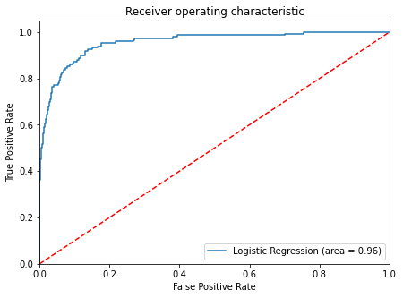

```python
logit_roc_auc_test = roc_auc_score(y_test, lg.predict_proba(X_test)[:, 1])
fpr, tpr, thresholds = roc_curve(y_test, lg.predict_proba(X_test)[:, 1])
plt.figure(figsize=(7, 5))
plt.plot(fpr, tpr, label="Logistic Regression (area = %0.2f)" % logit_roc_auc_test)
plt.plot([0, 1], [0, 1], "r--")
plt.xlim([0.0, 1.0])
plt.ylim([0.0, 1.05])
plt.xlabel("False Positive Rate")
plt.ylabel("True Positive Rate")
plt.title("Receiver operating characteristic")
plt.legend(loc="lower right")
plt.show()
```

### With threshold value of 0.11

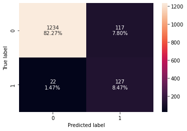

```python
# creating confusion matrix
confusion_matrix_sklearn_with_threshold(
    lg, X_test, y_test, threshold=optimal_threshold_auc_roc
)
```

```python
# checking model performance for this model
log_reg_model_test_perf_threshold_auc_roc = model_performance_classification_sklearn_with_threshold(
    lg, X_test, y_test, threshold=optimal_threshold_auc_roc
)
print("Test set performance:")
log_reg_model_test_perf_threshold_auc_roc
```

```
Test set performance:
```

|  | Accuracy | Recall | Precision | F1 |
| --- | --- | --- | --- | --- |
| 0 | 0.907333 | 0.852349 | 0.520492 | 0.64631 |

### With threshold value of 0.3

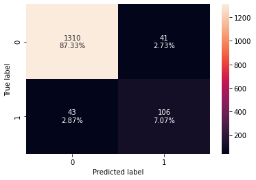

```python
# creating confusion matrix
confusion_matrix_sklearn_with_threshold(
    lg, X_test, y_test, threshold=optimal_threshold_curve
)
```

```python
log_reg_model_test_perf_threshold_curve = model_performance_classification_sklearn_with_threshold(
    lg, X_test, y_test, threshold=optimal_threshold_curve
)
print("Test performance:")
log_reg_model_test_perf_threshold_curve
```

```
Test performance:
```

|  | Accuracy | Recall | Precision | F1 |
| --- | --- | --- | --- | --- |
| 0 | 0.944 | 0.711409 | 0.721088 | 0.716216 |

```python
# training performance comparison

models_train_comp_df = pd.concat(
    [
        log_reg_model_train_perf.T,
        log_reg_model_train_perf_threshold_auc_roc.T,
        log_reg_model_train_perf_threshold_curve.T,
    ],
    axis=1,
)
models_train_comp_df.columns = [
    "Logistic Regression sklearn",
    "Logistic Regression-0.11 Threshold",
    "Logistic Regression-0.30 Threshold",
]

print("Training performance comparison:")
models_train_comp_df
```

```
Training performance comparison:
```

|  | Logistic Regression sklearn | Logistic Regression-0.11 Threshold | Logistic Regression-0.30 Threshold |
| --- | --- | --- | --- |
| Accuracy | 0.955714 | 0.909143 | 0.950857 |
| Recall | 0.658610 | 0.897281 | 0.782477 |
| Precision | 0.838462 | 0.511188 | 0.721448 |
| F1 | 0.737733 | 0.651316 | 0.750725 |

```python
# testing performance comparison

models_test_comp_df = pd.concat(
    [
        log_reg_model_test_perf.T,
        log_reg_model_test_perf_threshold_auc_roc.T,
        log_reg_model_test_perf_threshold_curve.T,
    ],
    axis=1,
)
models_test_comp_df.columns = [
    "Logistic Regression sklearn",
    "Logistic Regression-0.11 Threshold",
    "Logistic Regression-0.30 Threshold",
]

print("Test set performance comparison:")
models_test_comp_df
```

```
Test set performance comparison:
```

|  | Logistic Regression sklearn | Logistic Regression-0.11 Threshold | Logistic Regression-0.30 Threshold |
| --- | --- | --- | --- |
| Accuracy | 0.948667 | 0.907333 | 0.944000 |
| Recall | 0.590604 | 0.852349 | 0.711409 |
| Precision | 0.846154 | 0.520492 | 0.721088 |
| F1 | 0.695652 | 0.646310 | 0.716216 |

### Conclusion of Logistic Regression Model

- We have been able to build a predictive model that can be used by the bank to find the customers who avail a Personal Loan with a recall score of 0.89 on the training set and 0.85 o Testing set formulate policies accordingly.
- By changing the threshold of the logistic regression model we were able to see a significant improvement in the model performance.
- The model achieved a recall of 0.89 on the training set with threshold set at 0.11.
- The model achieved a recall of 0.85 on the testing set with threshold set at 0.11.

### Business Insights based on Logistic Regression Model

- Coefficients of Experience, Income, Family, CCAvg, Education, Mortgage, CD_Account and categorical variables of County are positive, an increase in these will lead to an increase in chances of a customer becoming a Personal Loan Customer.
- Coefficients of Securities_Account, Online, CreditCard and some categorical variables of County are negative, a increase in these will lead to an decrease in chances of a customer becoming a Personal Loan Customer.

## Building Decision Tree

### Model evaluation criterion

### Model can make wrong predictions as:

1. Predicting a customer is going to become a Personal Loan Customer - Loss of resources
2. Predicting a customer is not going to be a Perosnal Loan Customer but in reality the customer will likely avail of the Personal Loan - Loss of opportunity

### Which Loss is greater ?

- Loss of opportunity will be the greater loss as the bank will be losing a potential customer for Personal Loan.

### How to reduce this loss i.e need to reduce False Negatives ?

- Bank would want to reduce false negatives, this can be done by maximizing the Recall. Greater the recall lesser the chances of false negatives.

```python
# defining a function to compute different metrics to check performance of a classification model built using sklearn
def model_performance_classification_sklearn(model, predictors, target):
    """
    Function to compute different metrics to check classification model performance

    model: classifier
    predictors: independent variables
    target: dependent variable
    """

    # predicting using the independent variables
    pred = model.predict(predictors)

    acc = accuracy_score(target, pred)  # to compute Accuracy
    recall = recall_score(target, pred)  # to compute Recall
    precision = precision_score(target, pred)  # to compute Precision
    f1 = f1_score(target, pred)  # to compute F1-score

    # creating a dataframe of metrics
    df_perf = pd.DataFrame(
        {"Accuracy": acc, "Recall": recall, "Precision": precision, "F1": f1,},
        index=[0],
    )

    return df_perf
```

```python
def confusion_matrix_sklearn(model, predictors, target):
    """
    To plot the confusion_matrix with percentages

    model: classifier
    predictors: independent variables
    target: dependent variable
    """
    y_pred = model.predict(predictors)
    cm = confusion_matrix(target, y_pred)
    labels = np.asarray(
        [
            ["{0:0.0f}".format(item) + "\n{0:.2%}".format(item / cm.flatten().sum())]
            for item in cm.flatten()
        ]
    ).reshape(2, 2)

    plt.figure(figsize=(6, 4))
    sns.heatmap(cm, annot=labels, fmt="")
    plt.ylabel("True label")
    plt.xlabel("Predicted label")
```

```python
dtmodel = DecisionTreeClassifier(criterion="gini", random_state=1)
dtmodel.fit(X_train, y_train)
```

```
DecisionTreeClassifier(random_state=1)
```

### Checking model on Training Set

```python
decision_tree_perf_train = model_performance_classification_sklearn(
    dtmodel, X_train, y_train
)
decision_tree_perf_train
```

|  | Accuracy | Recall | Precision | F1 |
| --- | --- | --- | --- | --- |
| 0 | 1.0 | 1.0 | 1.0 | 1.0 |

Observation

- Highest Recall Value of 1.0
- Model is able to perfectly classify all the data points on the training set.
- This generally leads to overfitting of the model as Decision Tree will perform well on the training set but will fail to replicate the performance on the test set.

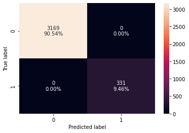

```python
confusion_matrix_sklearn(dtmodel, X_train, y_train)
```

### Checking model on Testing Set

```python
decision_tree_perf_test = model_performance_classification_sklearn(
    dtmodel, X_test, y_test
)
decision_tree_perf_test
```

|  | Accuracy | Recall | Precision | F1 |
| --- | --- | --- | --- | --- |
| 0 | 0.976 | 0.845638 | 0.906475 | 0.875 |

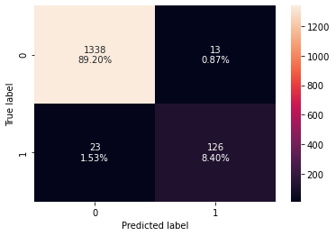

```python
confusion_matrix_sklearn(dtmodel, X_test, y_test)
```

Observation

- Model is giving good results on Testing set as well